# 4.10: Coding Etiquette & Excel Reporting

This notebook continues the analysis from Exercise 4.9 by incorporating demographic data to improve customer profiling. The goal is to answer key business questions and provide insights into customer behavior across different regions and demographics.

# Step 1: Load the cleaned and merged Instacart dataset

In this step, I loaded the merged dataset created in Exercise 4.9 using the read_pickle() function. This dataset includes information on orders, products, customer demographics, and a "new_customer" flag.

```python
import pandas as pd

# Load the merged data from 4.9
df = pd.read_pickle('/Users/canancengel/A4_Instacart Basket Analysis/02_Data/Prepared Data/df_merged_4_9.pkl')

# Quick check
df.head()
```

|  | order_id | user_id | order_number | order_dow | order_hour_of_day | days_since_prior_order | new_customer | product_id | add_to_cart_order | reordered | ... | aisle_id | department_id | prices | Gender | STATE | Age | date_joined | dependants | marital_status | income |
| --- | --- | --- | --- | --- | --- | --- | --- | --- | --- | --- | --- | --- | --- | --- | --- | --- | --- | --- | --- | --- | --- |
| 0 | 2539329 | 1 | 1 | 2 | 8 | NaN | True | 196 | 1 | 0 | ... | 77 | 7 | 9.0 | Female | Alabama | 31 | 2/17/2019 | 3 | married | 40423 |
| 1 | 2539329 | 1 | 1 | 2 | 8 | NaN | True | 14084 | 2 | 0 | ... | 91 | 16 | 12.5 | Female | Alabama | 31 | 2/17/2019 | 3 | married | 40423 |
| 2 | 2539329 | 1 | 1 | 2 | 8 | NaN | True | 12427 | 3 | 0 | ... | 23 | 19 | 4.4 | Female | Alabama | 31 | 2/17/2019 | 3 | married | 40423 |
| 3 | 2539329 | 1 | 1 | 2 | 8 | NaN | True | 26088 | 4 | 0 | ... | 23 | 19 | 4.7 | Female | Alabama | 31 | 2/17/2019 | 3 | married | 40423 |
| 4 | 2539329 | 1 | 1 | 2 | 8 | NaN | True | 26405 | 5 | 0 | ... | 54 | 17 | 1.0 | Female | Alabama | 31 | 2/17/2019 | 3 | married | 40423 |

5 rows × 22 columns

## Step 2: PII Risk Check

In this step, I examined the columns in the dataset to identify any potential Personally Identifiable Information (PII). The dataset contains only anonymized user IDs and general demographic or transactional data (e.g., age, gender, income, state). Therefore, there is no sensitive information that poses a privacy risk.

```python
# Display column names to assess any PII risk
df.columns
```

```
Index(['order_id', 'user_id', 'order_number', 'order_dow', 'order_hour_of_day',
       'days_since_prior_order', 'new_customer', 'product_id',
       'add_to_cart_order', 'reordered', '_merge', 'product_name', 'aisle_id',
       'department_id', 'prices', 'Gender', 'STATE', 'Age', 'date_joined',
       'dependants', 'marital_status', 'income'],
      dtype='object')
```

```python
# 1. Full name -> abbreviation
state_abbrev = {
    'Alabama': 'AL', 'Alaska': 'AK', 'Arizona': 'AZ', 'Arkansas': 'AR', 'California': 'CA',
    'Colorado': 'CO', 'Connecticut': 'CT', 'Delaware': 'DE', 'District of Columbia': 'DC',
    'Florida': 'FL', 'Georgia': 'GA', 'Hawaii': 'HI', 'Idaho': 'ID', 'Illinois': 'IL',
    'Indiana': 'IN', 'Iowa': 'IA', 'Kansas': 'KS', 'Kentucky': 'KY', 'Louisiana': 'LA',
    'Maine': 'ME', 'Maryland': 'MD', 'Massachusetts': 'MA', 'Michigan': 'MI', 'Minnesota': 'MN',
    'Mississippi': 'MS', 'Missouri': 'MO', 'Montana': 'MT', 'Nebraska': 'NE', 'Nevada': 'NV',
    'New Hampshire': 'NH', 'New Jersey': 'NJ', 'New Mexico': 'NM', 'New York': 'NY',
    'North Carolina': 'NC', 'North Dakota': 'ND', 'Ohio': 'OH', 'Oklahoma': 'OK', 'Oregon': 'OR',
    'Pennsylvania': 'PA', 'Rhode Island': 'RI', 'South Carolina': 'SC', 'South Dakota': 'SD',
    'Tennessee': 'TN', 'Texas': 'TX', 'Utah': 'UT', 'Vermont': 'VT', 'Virginia': 'VA',
    'Washington': 'WA', 'West Virginia': 'WV', 'Wisconsin': 'WI', 'Wyoming': 'WY'
}

# 2. Abbreviation -> Region
region_map = {
    # Northeast
    'CT': 'Northeast', 'ME': 'Northeast', 'MA': 'Northeast', 'NH': 'Northeast', 'RI': 'Northeast', 'VT': 'Northeast',
    'NJ': 'Northeast', 'NY': 'Northeast', 'PA': 'Northeast',
    # Midwest
    'IL': 'Midwest', 'IN': 'Midwest', 'MI': 'Midwest', 'OH': 'Midwest', 'WI': 'Midwest',
    'IA': 'Midwest', 'KS': 'Midwest', 'MN': 'Midwest', 'MO': 'Midwest', 'NE': 'Midwest', 'ND': 'Midwest', 'SD': 'Midwest',
    # South
    'DE': 'South', 'FL': 'South', 'GA': 'South', 'MD': 'South', 'NC': 'South', 'SC': 'South', 'VA': 'South',
    'DC': 'South', 'WV': 'South', 'AL': 'South', 'KY': 'South', 'MS': 'South', 'TN': 'South',
    'AR': 'South', 'LA': 'South', 'OK': 'South', 'TX': 'South',
    # West
    'AZ': 'West', 'CO': 'West', 'ID': 'West', 'MT': 'West', 'NV': 'West', 'NM': 'West', 'UT': 'West', 'WY': 'West',
    'AK': 'West', 'CA': 'West', 'HI': 'West', 'OR': 'West', 'WA': 'West'
}

# 3. Apply transformations
df['state_abbrev'] = df['STATE'].map(state_abbrev)
df['region'] = df['state_abbrev'].map(region_map)

# 4. Check results
df[['STATE', 'state_abbrev', 'region']].drop_duplicates().sort_values('STATE').head(10)
```

|  | STATE | state_abbrev | region |
| --- | --- | --- | --- |
| 0 | Alabama | AL | South |
| 59 | Alaska | AK | West |
| 254 | Arizona | AZ | West |
| 342 | Arkansas | AR | South |
| 360 | California | CA | West |
| 397 | Colorado | CO | West |
| 411 | Connecticut | CT | Northeast |
| 617 | Delaware | DE | South |
| 666 | District of Columbia | DC | South |
| 742 | Florida | FL | South |

## Step 3: Analyze Spending by Region

In this step, I analyzed whether there are differences in spending behavior across U.S. regions. First, I added a region variable based on the STATE column using U.S. Census regional classifications. Then, I grouped the data by region and loyalty_flag and calculated the average spending (prices). This helps identify how customer loyalty levels differ by region in terms of spending.

Source for region mapping: https://simple.wikipedia.org/wiki/List_of_regions_of_the_United_States

```python
# Loyalty flag: True if NOT a new customer
df['loyalty_flag'] = df['new_customer'].apply(lambda x: 'Loyal' if x == False else 'Not Loyal')

# Check result
df['loyalty_flag'].value_counts()
```

```
loyalty_flag
Loyal        30328763
Not Loyal     2076096
Name: count, dtype: int64
```

```python
import pandas as pd
import matplotlib.pyplot as plt
```

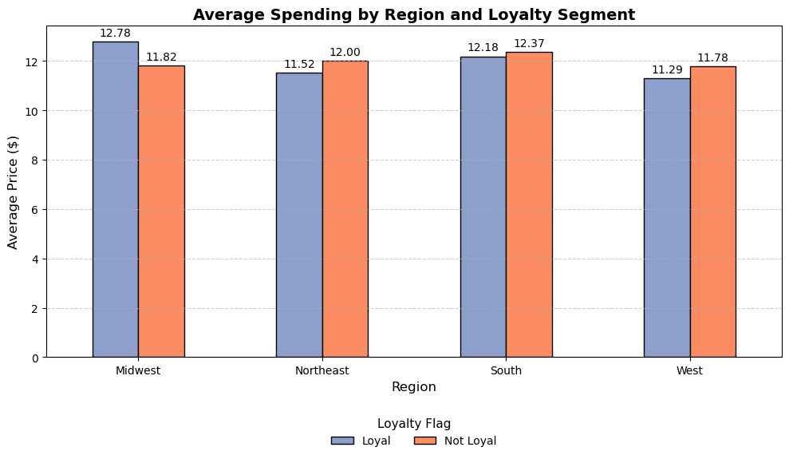

```python
import matplotlib.pyplot as plt

# Custom pastel colors
colors = ['#8DA0CB', '#FC8D62']  # Loyal (blue-gray), Not Loyal (orange-pink)

# Plot
ax = pivot_table.plot(kind='bar', figsize=(10, 6), color=colors, edgecolor='black')

# Titles and labels
plt.title('Average Spending by Region and Loyalty Segment', fontsize=14, fontweight='bold')
plt.xlabel('Region', fontsize=12)
plt.ylabel('Average Price ($)', fontsize=12)
plt.xticks(rotation=0)

# Legend at the bottom
plt.legend(
    title='Loyalty Flag',
    title_fontsize=11,
    fontsize=10,
    loc='lower center',
    bbox_to_anchor=(0.5, -0.3),
    ncol=2,
    frameon=False
)

# Value labels on bars
for container in ax.containers:
    ax.bar_label(container, fmt='%.2f', label_type='edge', fontsize=10, padding=3)

# Grid & layout
plt.grid(axis='y', linestyle='--', alpha=0.6)
plt.tight_layout()

# Save to file
plt.savefig('/Users/canancengel/A4_Instacart Basket Analysis/03_Analysis/Visualizations/region_loyalty_spending_bar_bottom_legend.png')
plt.show()
```

## Step 4: Filter Low-Activity Customers

```python
# Create exclusion flag for low-activity customers (less than 5 orders total)
df['exclusion_flag'] = df['order_number'] < 5

# Check how many customers will be excluded
exclusion_counts = df['exclusion_flag'].value_counts()
print(exclusion_counts)
```

```
exclusion_flag
False    24414877
True      7989982
Name: count, dtype: int64
```

```python
# Filter only active customers (who placed 5 or more orders)
df_active = df[df['exclusion_flag'] == False].copy()

# Quick check
df_active['user_id'].nunique()
```

```
162631
```

```python
# Save active users data
df_active.to_pickle('/Users/canancengel/A4_Instacart Basket Analysis/02_Data/Prepared Data/df_active_customers.pkl')
```

## Step 5: Create a Profiling Variable

```python
def profile_segment(row):
    if row['dependants'] >= 2 and row['income'] > 120000:
        return 'Parent, High Income'
    elif row['dependants'] >= 2:
        return 'Parent, Low/Med Income'
    elif row['dependants'] == 0 and row['Age'] < 35:
        return 'Young Adult, No Kids'
    elif row['dependants'] == 0 and row['Age'] >= 35:
        return 'Older Adult, No Kids'
    else:
        return 'Other'

# Apply to df_active
df_active['profile_segment'] = df_active.apply(profile_segment, axis=1)

# Quick check
df_active['profile_segment'].value_counts(dropna=False)
```

```
profile_segment
Parent, Low/Med Income    8602905
Other                     6082107
Older Adult, No Kids      4482917
Parent, High Income       3624863
Young Adult, No Kids      1622085
Name: count, dtype: int64
```

## Step 6: Create a Visualization for Profile Segments

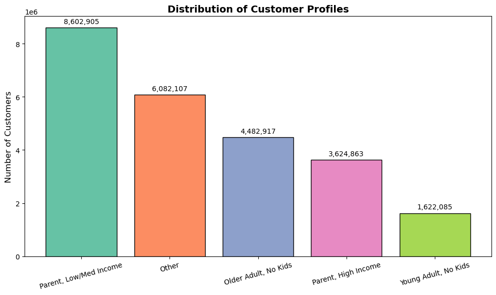

```python
import matplotlib.pyplot as plt

# Set color palette (4.9 style)
colors = ['#66c2a5', '#fc8d62', '#8da0cb', '#e78ac3', '#a6d854']

# Prepare data
profile_counts = df_active['profile_segment'].value_counts(dropna=False)

# Plotting
plt.figure(figsize=(10, 6))
bars = plt.bar(profile_counts.index, profile_counts.values, color=colors, edgecolor='black')

# Add value labels on top of bars
for bar in bars:
    yval = bar.get_height()
    plt.text(bar.get_x() + bar.get_width()/2, yval + 100000, f'{yval:,.0f}',
             ha='center', va='bottom', fontsize=10)

# Styling
plt.title('Distribution of Customer Profiles', fontsize=14, weight='bold')
plt.ylabel('Number of Customers', fontsize=12)
plt.xticks(rotation=15)
plt.tight_layout()

# Save figure
plt.savefig('/Users/canancengel/A4_Instacart Basket Analysis/03_Analysis/Visualizations/profile_segment_bar.png')
plt.show()
```

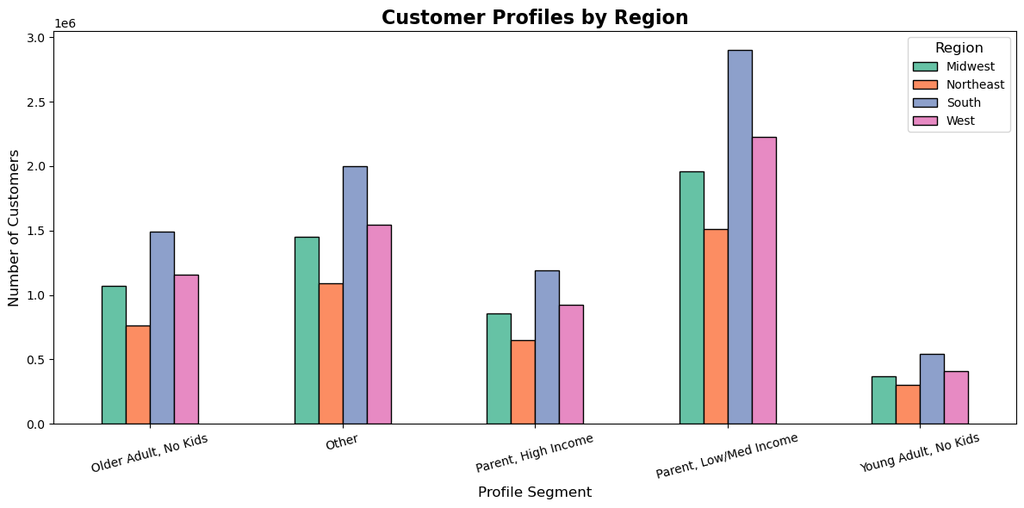

```python
import pandas as pd
import matplotlib.pyplot as plt

# Cross-tab for profile vs region
cross_region = pd.crosstab(df_active['profile_segment'], df_active['region'])

# Plot with enhancements
colors = ['#66c2a5', '#fc8d62', '#8da0cb', '#e78ac3']
ax = cross_region.plot(kind='bar', figsize=(12, 6), color=colors, edgecolor='black')

# Title and axis labels
plt.title('Customer Profiles by Region', fontsize=16, fontweight='bold')
plt.xlabel('Profile Segment', fontsize=12)
plt.ylabel('Number of Customers', fontsize=12)
plt.xticks(rotation=15, fontsize=10)
plt.yticks(fontsize=10)

# Legend formatting
plt.legend(title='Region', title_fontsize=12, fontsize=10, loc='upper right')

# Layout and save
plt.tight_layout()
plt.savefig('/Users/canancengel/A4_Instacart Basket Analysis/03_Analysis/Visualizations/profile_by_region_labeled.png')
plt.show()
```

## Step 7 – Create a Crosstab and Heatmap

Generate a crosstab to show the distribution of customer profiles by region.

```python
import seaborn as sns
import matplotlib.pyplot as plt
```

```python
crosstab = pd.crosstab(df_active['profile_segment'], df_active['region'])
```

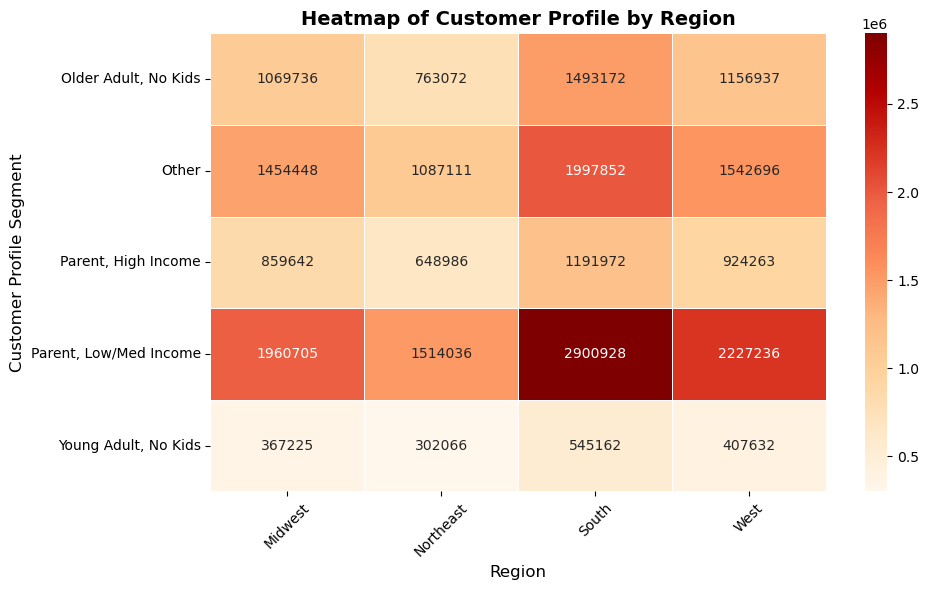

```python
# Step 7: Create Heatmap
plt.figure(figsize=(10, 6))
sns.heatmap(crosstab, annot=True, fmt='d', cmap='OrRd', linewidths=.5)

plt.title('Heatmap of Customer Profile by Region', fontsize=14, fontweight='bold')
plt.xlabel('Region', fontsize=12)
plt.ylabel('Customer Profile Segment', fontsize=12)
plt.xticks(rotation=45)
plt.yticks(rotation=0)
plt.tight_layout()
```

```python
# Save the figure
plt.savefig('/Users/canancengel/A4_Instacart Basket Analysis/03_Analysis/Visualizations/profile_region_heatmap.png')
plt.show()
```

# Step 8: Insights from Crosstab and Heatmap

The heatmap visualizes the distribution of customer profile segments across different U.S. regions.

This information can be useful for tailoring marketing strategies and customer outreach based on regional characteristics.

# Step 9: Filter & Export loyal customer segment to CSV

```python
loyal_customers = df[df['loyalty_flag'] == 'Loyal']

loyal_customers.to_csv(
    '/Users/canancengel/A4_Instacart Basket Analysis/02_Data/Prepared Data/loyal_customers.csv',
    index=False
)
```

# Step 10: Final Checks and Code Cleanup

Code is cleaned, well-commented, and consistent across the notebook.  
All outputs are saved in designated folders.